# RPostgreSQL

#### Other constraints

While a primary key essentially does this, we might want to set up a constraint to ensure no records are duplicated if, for example, we are using an auto-incrementing primary key.

```r
# set table schema with auto-incrementing primary key
DBI::dbSendQuery(con, 'CREATE TABLE IF NOT EXISTS population (id SERIAL PRIMARY KEY,
                 date VARCHAR(4), country VARCHAR(64), population NUMERIC);')

# add constraint so we don't accidently add duplicate records
DBI::dbSendQuery(con, "ALTER TABLE population ADD CONSTRAINT nodup UNIQUE (date, country, population);")

# add data
DBI::dbSendQuery(con, "INSERT INTO population (date, country, population) VALUES ('2019', 'UK', 66.65);")

# add duplicate data
DBI::dbSendQuery(con, "INSERT INTO population (date, country, population) VALUES ('2019', 'UK', 66.65);")
```

> Error in postgresqlExecStatement(conn, statement, …) : RS-DBI driver: (could not Retrieve the result : ERROR: duplicate key value violates unique constraint “nodup” DETAIL: Key (date, country, population)=(2019, UK, 66.65) already exists. )

Here we get an error if we try and add in a duplicate observation. We should tell postgres what to do if we get a violation of our constraint:

*do nothing on violation:* If we want to do nothing on any constraint violation (primary key or unique constraint) then we don’t need to specify a specific `ON CONSTRAINT`:

```r
# try to add data
DBI::dbGetQuery(con, "INSERT INTO population (date, country, population) VALUES ('2019', 'UK', 66.65) ON CONFLICT DO NOTHING;")
```

```
## data frame with 0 columns and 0 rows
```

*update violation with incoming data:*

```r
# try to add data
DBI::dbGetQuery(con, "INSERT INTO population (date, country, population) VALUES ('2019', 'UK', 66.65) ON CONFLICT ON CONSTRAINT nodup DO UPDATE SET (date, country, population) = (EXCLUDED.date, EXCLUDED.country, EXCLUDED.population);")
```

```
## data frame with 0 columns and 0 rows
```

*update violation with some existing data:*

```r
# try to add data
DBI::dbGetQuery(con, "INSERT INTO population (date, country, population) VALUES ('2019', 'UK', 66.65) ON CONFLICT ON CONSTRAINT nodup DO UPDATE SET (date, country, population) = (population.date, population.country, EXCLUDED.population);")
```

```
## data frame with 0 columns and 0 rows
```

### Querying a table

It is obvious from the previous sections that we can send a sql query with a combination of `glue_sql` and `dbSendQuery`. We can also make use of `dplyr` syntax using:

```r
tbl(con, 'iris_3')
```

```
## # Source:   table<iris_3> [?? x 6]
## # Database: postgres 12.2.0 [postgres@localhost:5432/testdatabase]
##    row_number sepal_length sepal_width petal_length petal_width species
##         <int>        <dbl>       <dbl>        <dbl>       <dbl> <chr>
##  1          1          5.1         3.5          1.4         0.2 setosa
##  2          2          4.9         3            1.4         0.2 setosa
##  3          3          4.7         3.2          1.3         0.2 setosa
##  4          4          4.6         3.1          1.5         0.2 setosa
##  5          5          5           3.6          1.4         0.2 setosa
##  6          6          5.4         3.9          1.7         0.4 setosa
##  7          7          4.6         3.4          1.4         0.3 setosa
##  8          8          5           3.4          1.5         0.2 setosa
##  9          9          4.4         2.9          1.4         0.2 setosa
## 10         10          4.9         3.1          1.5         0.1 setosa
## # … with more rows
```

`tbl` doesn’t return the full database but a sample of the result for speed purposes. If we want to return the full result so we can use the object in R for further analysis, we use `collect`:

```r
tbl(con, 'iris_3') %>%
  collect()
```

```
## # A tibble: 150 x 6
##    row_number sepal_length sepal_width petal_length petal_width species
##  *      <int>        <dbl>       <dbl>        <dbl>       <dbl> <chr>
##  1          1          5.1         3.5          1.4         0.2 setosa
##  2          2          4.9         3            1.4         0.2 setosa
##  3          3          4.7         3.2          1.3         0.2 setosa
##  4          4          4.6         3.1          1.5         0.2 setosa
##  5          5          5           3.6          1.4         0.2 setosa
##  6          6          5.4         3.9          1.7         0.4 setosa
##  7          7          4.6         3.4          1.4         0.3 setosa
##  8          8          5           3.4          1.5         0.2 setosa
##  9          9          4.4         2.9          1.4         0.2 setosa
## 10         10          4.9         3.1          1.5         0.1 setosa
## # … with 140 more rows
```

We can use typical `dplyr` syntax to query our data as an alternative to `dbSendQuery`. `dplyr` will convert our `dplyr` syntax into SQL code!

```r
tbl(con, 'iris_3') %>%
  group_by(species) %>%
  summarise(avg_length = mean(sepal_length)) %>%
  collect()
```

```
## # A tibble: 3 x 2
##   species    avg_length
## * <chr>           <dbl>
## 1 setosa           5.01
## 2 virginica        6.59
## 3 versicolor       5.94
```

We can see what code was run in SQL:

```r
tbl(con, 'iris_3') %>%
  group_by(species) %>%
  summarise(avg_length = mean(sepal_length)) %>%
  show_query()
```

```
## <SQL>
## SELECT "species", AVG("sepal_length") AS "avg_length"
## FROM "iris_3"
## GROUP BY "species"
```

## 2. POSTGIS

### Set up postgis sending queries with DBGetQuery

Run the following commands (or run in psql in terminal) to initialise postgis on our database:

```r
dbGetQuery(con, 'create extension postgis;')
dbGetQuery(con, 'create extension fuzzystrmatch;')
dbGetQuery(con, 'create extension postgis_tiger_geocoder;')
dbGetQuery(con, 'create extension postgis_topology;')
```

#### Writing a spatial table

Writing a spatial file to a database from R is best done using the `sf` packages and `sf::write_sf`:

```r
library(sf)
uk_auth <- read_sf('https://opendata.arcgis.com/datasets/d54f953d633b45f5a82fdd3c89b4c955_0.geojson')

write_sf(uk_auth, con, 'uk_authorities')
```

#### Set a spatial index

To speed up queries on our spatial table we generally want to set a spatial index:

```r
dbSendQuery(con, 'CREATE INDEX auth_gpx ON uk_authorities USING GIST (geography(geometry))')
```

```
## <PostgreSQLResult>
```

#### Querying a spatial table

Because dplyr doesn’t understand the column with class ‘geometry’, we cannot really query using the `tbl` method.

We will have to form the query ourselves, for example to get the local authority containing the point 51.5082, -0.0759 (Tower of London) we will have to use `glue_sql`:

```r
lat <-  51.5082
lng <- -0.0759
query <- glue_sql(
  "SELECT * FROM uk_authorities
  WHERE ST_INTERSECTS(geometry,ST_SetSRID(ST_MakePoint({lng},{lat}),4326))"
  ,.con=con)

tower_auth <- read_sf(con, query = query)
tower_auth
```

```
## Simple feature collection with 1 feature and 6 fields
## geometry type:  MULTIPOLYGON
## dimension:      XY
## bbox:           xmin: -0.07940341 ymin: 51.48599 xmax: 0.009089509 ymax: 51.54469
## epsg (SRID):    4326
## proj4string:    +proj=longlat +datum=WGS84 +no_defs
## # A tibble: 1 x 7
##   objectid cmlad11cd cmlad11nm cmlad11nmw st_areashape st_lengthshape
##      <int> <chr>     <chr>     <chr>             <dbl>          <dbl>
## 1      321 E41000321 Tower Ha… " "           19771465.         27476.
## # … with 1 more variable: geometry <MULTIPOLYGON [°]>
```

Just for fun, visualise result:

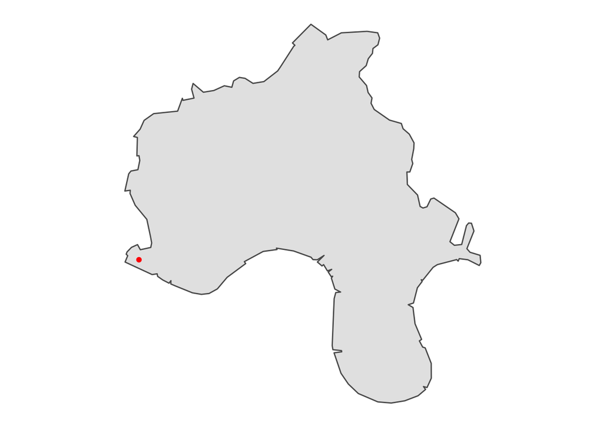

```r
library(ggplot2)
ggplot(tower_auth) +
  geom_sf() +
  geom_sf(data = st_as_sf(data.frame(lat, lng ), coords = c('lng','lat'), crs=4326), color='red') +
  ggthemes::theme_map()
```

## Dump our db to a file

cd to the directory we want to save the db dump in and run:

```bash
pg_dump --port=5432 --username=postgres --dbname=testdatabase --file=postgresdump.sql
```

## 3. Finally… close the connection

Close the connection:

```r
DBI::dbDisconnect(con)
```

Sometimes we can accumulate multiple connections, often resulting in the error that we’ve opened the *maximum number of connections*. We can loop through all of them and close them all:

```r
lapply(dbListConnections(PostgreSQL()), dbDisconnect)
```

```
## [[1]]
## [1] TRUE
```

#### Using on.exit

Of course it’s best practice to not accumulate connections in the first place. If using a function that opens a connection each time it’s run, it’s best to ensure it gets closed using `on.exit`:

```r
library(dplyr)
library(dbplyr)
db_fn <- function() {
  on.exit(dbDisconnect(con))
  con <- RPostgreSQL::dbConnect(RPostgreSQL::PostgreSQL(),
                              dbname = "testdatabase",
                              host = 'localhost',
                              user = "postgres",
                              password = Sys.getenv('PG_PASS'))

  tbl(con, 'iris_3') %>%
    collect()
}

db_fn()
```

```
## # A tibble: 150 x 6
##    row_number sepal_length sepal_width petal_length petal_width species
##  *      <int>        <dbl>       <dbl>        <dbl>       <dbl> <chr>
##  1          1          5.1         3.5          1.4         0.2 setosa
##  2          2          4.9         3            1.4         0.2 setosa
##  3          3          4.7         3.2          1.3         0.2 setosa
##  4          4          4.6         3.1          1.5         0.2 setosa
##  5          5          5           3.6          1.4         0.2 setosa
##  6          6          5.4         3.9          1.7         0.4 setosa
##  7          7          4.6         3.4          1.4         0.3 setosa
##  8          8          5           3.4          1.5         0.2 setosa
##  9          9          4.4         2.9          1.4         0.2 setosa
## 10         10          4.9         3.1          1.5         0.1 setosa
## # … with 140 more rows
```